# Exercise 03

Author

Nianzhen Gu (NianzhenGu)

Published

October 8, 2023

## Exploratory Data Analysis

Do an exploratory data analysis of a matrix of expression values. The data consists of expression values for samples that were treated with DMSO and TSA. The samples were measured using three technologies: bulk, IFC96, IFC800. See the two RDS files `counts.RDS` and `phenodata.RDS`.

The experiment has two experimental factors “Treatment” and “Technology”. Treatment has two levels, Technology has three levels. Samples that have the same combination of Treatment & Technology are replicates.

## Data Import

```r
x = readRDS("counts.RDS")
anno = readRDS("phenodata.RDS")
head(anno)
```

```
                      Treatment Technology
bulk.DMSO-Pre-96IFC        DMSO       bulk
bulk.TSA-Pre-96IFC          TSA       bulk
bulk.DMSO-Pre-800IFC       DMSO       bulk
bulk.TSA-Pre-800IFC         TSA       bulk
bulk.DMSO-Post-800IFC      DMSO       bulk
bulk.TSA-Post-800IFC        TSA       bulk
```

## Compute and visualize basic statistics on the experimental design

How many replicates are there for each combination of factor levels? How many genes have an expression value above 0 in each sample? Are there systematic differences between the samples in the different conditions (treatment & technology). Visualize the following statistics per sample:

How many replicates are there for each combination of factor levels?

```r
comb_max <- matrix(0, nrow = 3, ncol = 2)
rownames(comb_max) <- c("bulk","IFC96","IFC800")
colnames(comb_max) <- c("DMSO","TSA")

for (i in 1:nrow(anno)) {
  treatment <- anno[i,1]
  technology <- anno[i,2]

  comb_max[technology, treatment] <- comb_max[technology, treatment]+1
}

print(comb_max)
```

```
       DMSO TSA
bulk      3   3
IFC96    20  20
IFC800   20  20
```

How many genes have an expression value above 0 in each sample?

```r
sample_name <- colnames(x)
num_genes_above_zero <- apply(x > 0, 2, sum)
cat("Number of genes with expression values above 0 in each sample:\n")
```

```
Number of genes with expression values above 0 in each sample:
```

```r
for (i in seq_along(num_genes_above_zero)) {
  cat(sample_name[i], ":", num_genes_above_zero[i], "\n")
}
```

```
bulk.DMSO-Pre-96IFC : 15163
bulk.TSA-Pre-96IFC : 15261
bulk.DMSO-Pre-800IFC : 15404
bulk.TSA-Pre-800IFC : 16182
bulk.DMSO-Post-800IFC : 15202
bulk.TSA-Post-800IFC : 16167
ifc96.LIB018588_GEN00046618_S78_L001 : 7862
ifc96.LIB018588_GEN00046619_S79_L001 : 8537
ifc96.LIB018588_GEN00046620_S80_L001 : 404
ifc96.LIB018588_GEN00046621_S81_L001 : 7479
ifc96.LIB018588_GEN00046622_S82_L001 : 7003
ifc96.LIB018588_GEN00046623_S83_L001 : 8886
ifc96.LIB018588_GEN00046624_S84_L001 : 9314
ifc96.LIB018588_GEN00046625_S85_L001 : 8616
ifc96.LIB018588_GEN00046626_S86_L001 : 5450
ifc96.LIB018588_GEN00046627_S87_L001 : 7121
ifc96.LIB018588_GEN00046628_S88_L001 : 557
ifc96.LIB018588_GEN00046629_S89_L001 : 6697
ifc96.LIB018588_GEN00046630_S90_L001 : 9123
ifc96.LIB018588_GEN00046631_S91_L001 : 8138
ifc96.LIB018588_GEN00046632_S92_L001 : 8781
ifc96.LIB018588_GEN00046633_S93_L001 : 8199
ifc96.LIB018588_GEN00046634_S94_L001 : 8987
ifc96.LIB018588_GEN00046635_S95_L001 : 8948
ifc96.LIB018588_GEN00046636_S96_L001 : 8845
ifc96.LIB018589_GEN00046637_S97_L002 : 7644
ifc96.LIB018589_GEN00046638_S98_L002 : 8639
ifc96.LIB018589_GEN00046639_S99_L002 : 9019
ifc96.LIB018589_GEN00046640_S100_L002 : 7882
ifc96.LIB018589_GEN00046641_S101_L002 : 8858
ifc96.LIB018589_GEN00046642_S102_L002 : 8027
ifc96.LIB018589_GEN00046643_S103_L002 : 8793
ifc96.LIB018589_GEN00046644_S104_L002 : 7550
ifc96.LIB018589_GEN00046645_S105_L002 : 7126
ifc96.LIB018589_GEN00046646_S106_L002 : 7830
ifc96.LIB018589_GEN00046647_S107_L002 : 9012
ifc96.LIB018589_GEN00046648_S108_L002 : 7808
ifc96.LIB018589_GEN00046649_S109_L002 : 8691
ifc96.LIB018589_GEN00046650_S110_L002 : 8340
ifc96.LIB018589_GEN00046651_S111_L002 : 8389
```

[output cut: 31 more lines]

```
ifc800.COL11_ROW06_LIB018723-GEN00047362 : 1564
ifc800.COL11_ROW07_LIB018723-GEN00047362 : 6811
ifc800.COL11_ROW08_LIB018723-GEN00047362 : 5729
ifc800.COL11_ROW09_LIB018723-GEN00047362 : 8379
ifc800.COL11_ROW10_LIB018723-GEN00047362 : 5157
ifc800.COL11_ROW11_LIB018723-GEN00047362 : 5840
ifc800.COL11_ROW12_LIB018723-GEN00047362 : 9272
ifc800.COL11_ROW13_LIB018723-GEN00047362 : 8320
ifc800.COL11_ROW14_LIB018723-GEN00047362 : 5239
ifc800.COL11_ROW15_LIB018723-GEN00047362 : 5442
ifc800.COL11_ROW16_LIB018723-GEN00047362 : 1125
ifc800.COL11_ROW17_LIB018723-GEN00047362 : 4682
ifc800.COL11_ROW18_LIB018723-GEN00047362 : 5005
ifc800.COL11_ROW19_LIB018723-GEN00047362 : 9074
ifc800.COL11_ROW20_LIB018723-GEN00047362 : 6029
```

Are there systematic differences between the samples in the different conditions (treatment & technology)？

From the above values, we can see that there are differences between the samples in the different conditions in terms of gene expression values.

number of detected genes (Color the samples by the experimental condition.)

```r
library(ggplot2)

sample_condition_table <- data.frame(Sample_Names = sample_name,
                      Number_of_Genes = 0,
                      Sum_of_Reads = 0) # create a dataframe to store the number of zeros in each sample

for (sample in sample_name) {
  category <- paste(anno[sample, "Treatment"],
                    anno[sample, "Technology"],
                    sep = "&")
  count_zero <- sum(x[, sample] == 0) # count 0 in each sample
  num_genes <- nrow(x) - count_zero # genes number, for later use
  sum_reads <- sum(x[, sample]) # sum of reads, for later use

  sample_condition_table[sample_condition_table$Sample_Names==sample, "Number_of_Genes"] <- num_genes
  sample_condition_table[sample_condition_table$Sample_Names==sample, "Sum_of_Reads"] <- sum_reads
  sample_condition_table[sample_condition_table$Sample_Names==sample, "Category"] <- category
}

head(sample_condition_table)
```

```
           Sample_Names Number_of_Genes Sum_of_Reads  Category
1   bulk.DMSO-Pre-96IFC           15163     16469072 DMSO&bulk
2    bulk.TSA-Pre-96IFC           15261     10899777  TSA&bulk
3  bulk.DMSO-Pre-800IFC           15404     22928016 DMSO&bulk
4   bulk.TSA-Pre-800IFC           16182     21170430  TSA&bulk
5 bulk.DMSO-Post-800IFC           15202     16572277 DMSO&bulk
6  bulk.TSA-Post-800IFC           16167     21218842  TSA&bulk
```

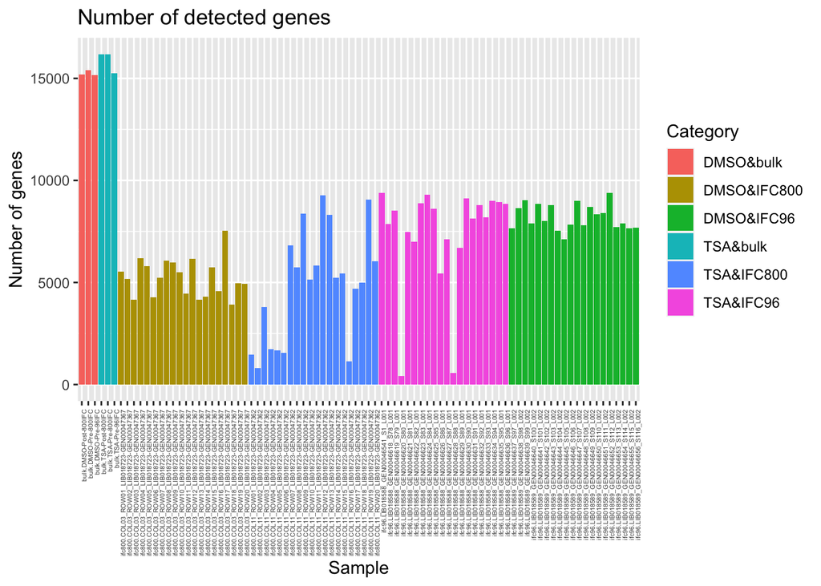

```r
ggplot(sample_condition_table, aes(x = Sample_Names, y = Number_of_Genes, fill = Category)) +
  geom_bar(stat = "identity") +
  labs(title = "Number of detected genes", x = "Sample", y = "Number of genes") +
  theme(axis.text.x = element_text(angle = 90, hjust = 1, size=4))
```

total sum of counts per sample (serves as a proxy for the number of sequenced reads per sample) (Color the samples by the experimental condition.)

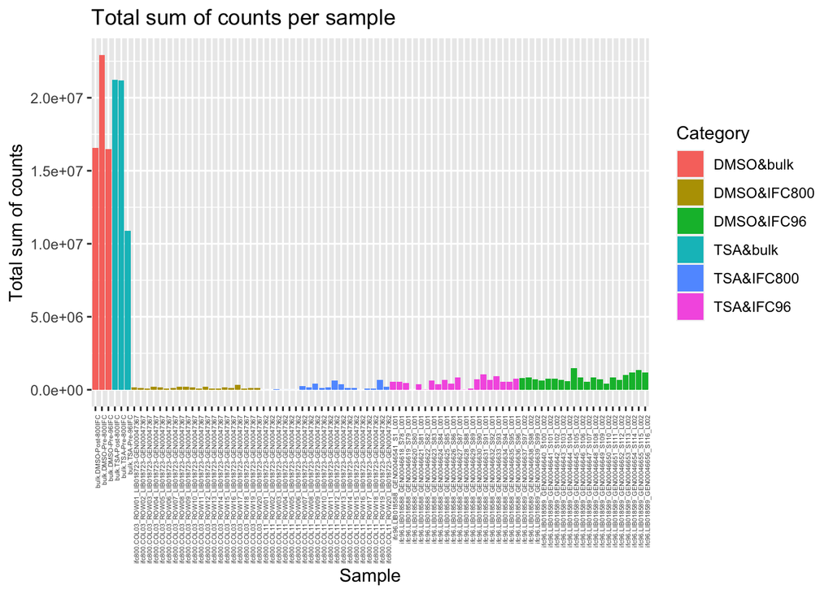

```r
ggplot(sample_condition_table, aes(x = Sample_Names, y = Sum_of_Reads, fill = Category)) +
  geom_bar(stat = "identity") +
  labs(title = "Total sum of counts per sample", x = "Sample", y = "Total sum of counts") +
  theme(axis.text.x = element_text(angle = 90, hjust = 1, size=4))
```

## Normalize the data

Scale the columns so that the total sum of all columns are identical

```r
# install.packages("BiocManager")
# library(BiocManager)
# BiocManager::install("preprocessCore")

library(preprocessCore)
normalized_data <- normalize.quantiles(x, keep.names = TRUE)
```

## Transform the data to log-scale

Use the function `log1p` to transform the data to log-scale

```r
# Apply log1p transformation to each element
log_scaled_data <- log1p(normalized_data)
```

## Visualize the distribution of the expression values

Use violin plots and boxplots to visualize the distribution of the expression values. Aggregate the replicates in the same experimental group into one average sample, and plot the averaged sample. Color by experimental factors.

```r
categories <- unique(sample_condition_table$Category)
gene_names <- rownames(x)

# Filter the table based on the specified categories
filtered_data <- sample_condition_table[sample_condition_table$Category %in% categories, ]

# Get the names for each category
result <- split(filtered_data$Sample_Names, filtered_data$Category)


average_matrix <- matrix(0, nrow = length(gene_names), ncol = length(categories), dimnames = list(gene_names, categories))


for (category in categories) {
  sum <- rowSums(log_scaled_data[, result[[category]]])
  average_matrix[, category] <- sum / length(result[[category]])
}

head(average_matrix)
```

```
            DMSO&bulk   TSA&bulk TSA&IFC96 DMSO&IFC96 DMSO&IFC800 TSA&IFC800
OR4F5      0.03666697 0.00000000 0.3568216  0.1486603   0.6337874  0.8483753
FO538757.3 0.03666697 0.01532635 0.3568216  0.1486603   0.6337874  0.8483753
FO538757.2 2.68169175 2.47932593 1.2602580  1.7916845   2.8643237  1.3992718
OR4F29     0.00000000 0.00000000 0.3568216  0.1486603   0.6337874  0.8483753
OR4F16     0.00000000 0.00000000 0.3568216  0.1486603   0.6337874  0.8483753
LINC01128  0.56052330 0.49617104 0.3568216  0.9226538   0.6337874  0.8483753
```

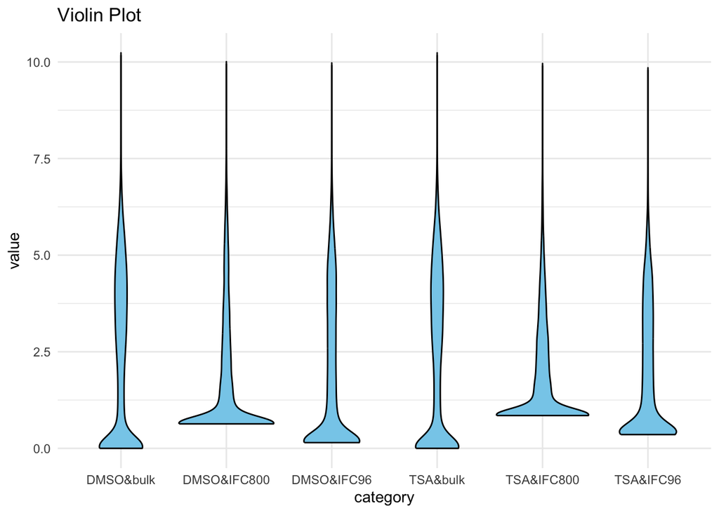

```r
# Load the required packages
library(ggplot2)
library(tidyr)
library(patchwork)

average_df <- as.data.frame(average_matrix)
average_df_long <- gather(average_df, key = "category", value = "value")

# Create a violin plot
violin_plot <- ggplot(average_df_long, aes(x = category, y = value)) +
  geom_violin(fill = "skyblue", color = "black") +
  labs(title = "Violin Plot") +
  theme_minimal()

# Create a box plot
box_plot <- ggplot(average_df_long, aes(x = category, y = value)) +
  geom_boxplot(fill = "skyblue", color = "black") +
  labs(title = "Box Plot") +
  theme_minimal()

violin_plot
```

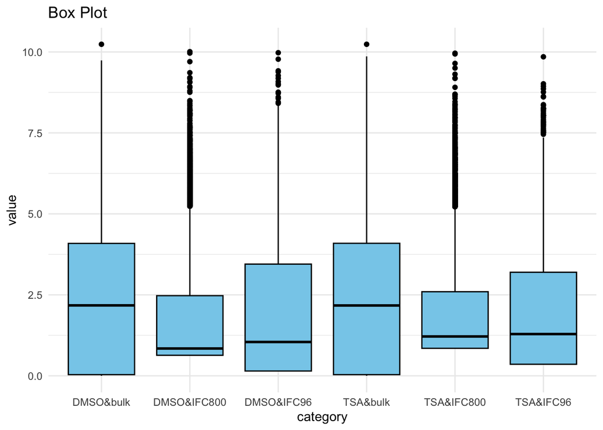

```r
box_plot
```

## Most variable genes

Identify the 500 most variable genes (with largest variance across samples) and continue working with those

```r
variance <- apply(log_scaled_data, 1, var)
sorted_variances <- sort(variance, decreasing = TRUE)
top500 <- sorted_variances[1:500]
print(names(top500))
```

```
  [1] "EEF1A1"         "NUDT19"         "TOP2A"          "TSPYL1"
  [5] "RRM2"           "EREG"           "RP11-872D17.8"  "SLC35F2"
  [9] "CDK1"           "SH3D19"         "ELMSAN1"        "CHP1"
 [13] "MKI67"          "BICC1"          "SRSF6"          "SNX32"
 [17] "KIAA1467"       "PNPO"           "SLC25A5-AS1"    "CACUL1"
 [21] "SNX22"          "RAP2B"          "NT5DC3"         "ATG10"
 [25] "ELF3"           "RP11-500M8.7"   "MT-ND6"         "SERPINB10"
 [29] "EDEM1"          "KRT16"          "RP11-513I15.6"  "RP11-426L16.10"
 [33] "ETNK1"          "PPP1CB"         "NCAPG"          "ACTB"
 [37] "UBXN11"         "PHC3"           "CCNB2"          "CDC42BPA"
 [41] "NDC80"          "SGPL1"          "PARD6B"         "TOB1"
 [45] "PLK1"           "AURKB"          "PAN3"           "C16orf72"
 [49] "C15orf52"       "SEMA3A"         "BAG4"           "EYA3"
 [53] "SERPINB2"       "CDCA8"          "SLC30A7"        "ATP6V1C2"
 [57] "DOCK5"          "MAST3"          "LLfos-48D6.2"   "PIP4K2A"
```

[output cut: 110 more lines]

## Sample correlations

Compute and visualize the sample-to-sample correlations

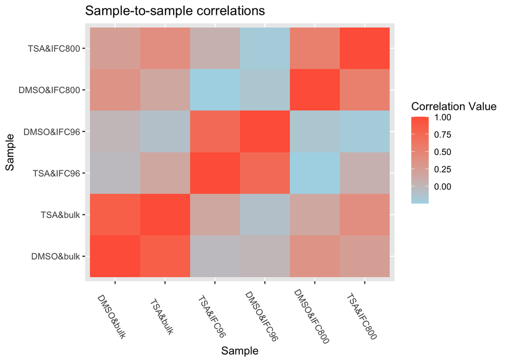

```r
average_df2 <- as.data.frame(average_df[names(top500), ])
correlations <- cor(average_df2, method = "pearson")

# Visualization
library(reshape2)
correlation_plot <- ggplot(data = melt(correlations),
             aes(x = Var1, y = Var2, fill = value)) +
  geom_tile() +
  scale_fill_gradient(low = "lightblue", high = "tomato") +
  labs(title = "Sample-to-sample correlations",
       x = "Sample",
       y = "Sample",
       fill = "Correlation Value") +
  theme(axis.text.x = element_text(angle = 300))
correlation_plot
```

## Clustering

Compute and visualize a hierarchical clustering of the samples, use the method `hclust`

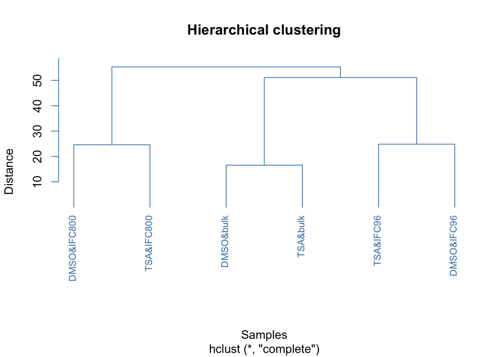

```r
clustering <- hclust(dist(t(average_df2)))
plot(clustering, main = "Hierarchical clustering",
     xlab = "Samples", ylab = "Distance",
     labels = colnames(average_df2),
     hang = -1, col = "steelblue", cex = 0.8)
```

## Heatmap

Use the package `pheatmap` to generate a heatmap of the expression data.

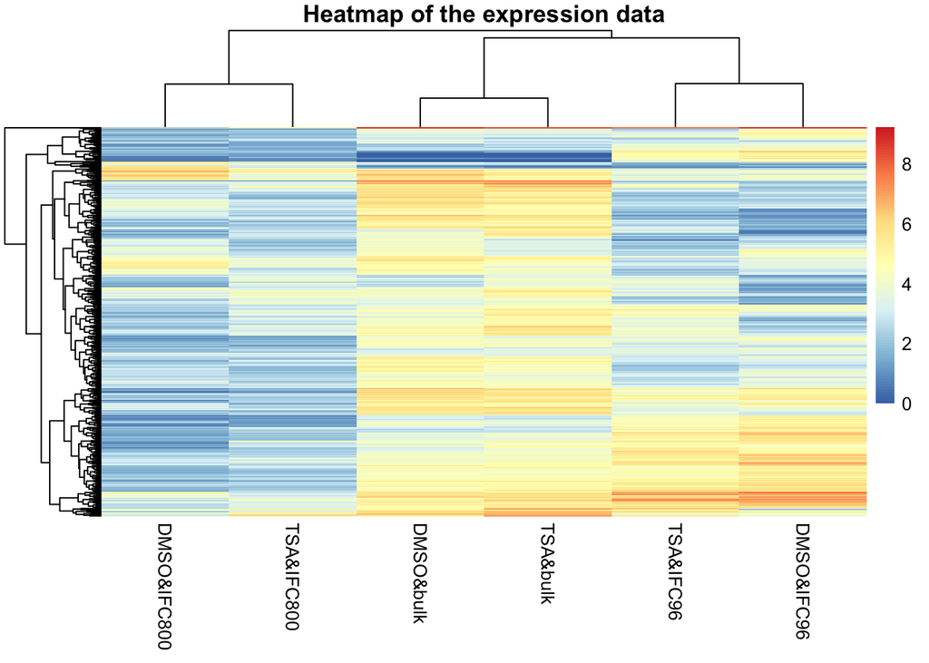

```r
library(pheatmap)
pheatmap(average_df2, main = "Heatmap of the expression data", show_rownames = FALSE)
```